# 배틀필드5와 콜오브듀티: 블랙옵스4의 논란 이후 게이머 반응 연구

신문방송학과 14012148 이명우

2018년 6월 29일

# 연구배경

FPS게임을 즐겨하는 게이머라면 모를 수 없는 게임 시리즈가 있습니다. 바로 해외의 유명 FPS게임인 ‘배틀필드’와 ‘콜오브듀티’가 바로 그렇습니다. 배틀필드 시리즈와 콜오브듀티 시리즈는 각각 2002년과 2003년에 처음 발매를 시작해서 현재까지도 계속해서 신작 게임이 출시하고 있으며, 오는 10월 12일에 하더라도 콜오브듀티: 블랙옵스4가, 11월 20일에는 배틀필드5가 정식출시를 앞두고 있습니다. 그러나 공교롭게도 두 게임 모두 게이머로부터 논란을 얻고 있는 상태입니다. 배틀필드5는 기존의 배틀필드 시리즈와는 확연히 다른 플레이방식 때문에, 그리고 콜오브듀티: 블랙옵스4는 싱글플레이 캠페인의 명가라고 칭송 받던 콜오브듀티 시리즈 인데, 바로 그 싱글플레이 방식을 버리고 오로지 멀티플레이 방식에만 중점을 두겠다는 발표 때문입니다. 따라서, 확실한 라이벌 구도를 형성 중이었던 두 게임 시리즈가, 이번 논란에서는 과연 어떤 반응을 게이머부터 얻을지 각각 알아보고자 하였습니다.

# 데이터 수집

<표1. 데이터 수집 키워드>

| 배틀필드 | ▲battlefield5 ▲battlefieldv ▲bf5 ▲bfv |
| --- | --- |
| 블랙옵스 | ▲blackops4 ▲blackopsiiii ▲blackopsiv ▲bo4 |

각각의 키워드를 통해 트위터 데이터 수집하였습니다.

<코드1. 데이터 수집에 사용한 패키지>

```r
library(httpuv)
library(rtweet)
```

<코드2. 배틀필드 데이터 수집>

```r
#6월9일
tweets_1_battlefield5_0609 <- search_tweets("battlefield5", n = 30000, retryonratelimit = TRUE)
tweets_1_battlefieldv_0609 <- search_tweets("battlefieldv", n = 30000, retryonratelimit = TRUE)
tweets_1_bf5_0609 <- search_tweets("bf5", n = 30000, retryonratelimit = TRUE)
tweets_1_bfv_0609 <- search_tweets("bfv", n = 30000, retryonratelimit = TRUE)

save(tweets_1_battlefield5_0609,
     tweets_1_battlefieldv_0609,
     tweets_1_bf5_0609,
     tweets_1_bfv_0609,
     file="battlefield_0609.RData")

#6월10일
tweets_1_battlefield5_0610 <- search_tweets("battlefield5", n = 18000)
tweets_1_battlefieldv_0610 <- search_tweets("battlefieldv", n = 18000)
tweets_1_bf5_0610 <- search_tweets("bf5", n = 18000)
tweets_1_bfv_0610 <- search_tweets("bfv", n = 18000)

tweets_1_battlefield5_0610_2 <- search_tweets("battlefield5", n = 18000)
tweets_1_battlefieldv_0610_2 <- search_tweets("battlefieldv", n = 18000)
tweets_1_bf5_0610_2 <- search_tweets("bf5", n = 18000)
tweets_1_bfv_0610_2 <- search_tweets("bfv", n = 18000)

save(tweets_1_battlefield5_0610,
     tweets_1_battlefieldv_0610,
     tweets_1_bf5_0610,
     tweets_1_bfv_0610,
     tweets_1_battlefield5_0610_2,
     tweets_1_battlefieldv_0610_2,
     tweets_1_bf5_0610_2,
     tweets_1_bfv_0610_2,
     file="battlefield_0610.RData")

#6월11일
tweets_1_battlefield5_0611 <- search_tweets("battlefield5", n = 9000)
tweets_1_battlefieldv_0611 <- search_tweets("battlefieldv", n = 9000)
tweets_1_bf5_0611 <- search_tweets("bf5", n = 9000)
tweets_1_bfv_0611 <- search_tweets("bfv", n = 9000)

save(tweets_1_battlefield5_0611,
     tweets_1_battlefieldv_0611,
     tweets_1_bf5_0611,
     tweets_1_bfv_0611,
     file="battlefield_0611.RData")

#6월12일
tweets_1_battlefield5_0612 <- search_tweets("battlefield5", n = 9000)
tweets_1_battlefieldv_0612 <- search_tweets("battlefieldv", n = 9000)
tweets_1_bf5_0612 <- search_tweets("bf5", n = 9000)
tweets_1_bfv_0612 <- search_tweets("bfv", n = 9000)

tweets_1_battlefield5_0612_2 <- search_tweets("battlefield5", n = 9000)
tweets_1_battlefieldv_0612_2 <- search_tweets("battlefieldv", n = 9000)
tweets_1_bf5_0612_2 <- search_tweets("bf5", n = 9000)
tweets_1_bfv_0612_2 <- search_tweets("bfv", n = 9000)

save(tweets_1_battlefield5_0612,
     tweets_1_battlefieldv_0612,
     tweets_1_bf5_0612,
     tweets_1_bfv_0612,
     tweets_1_battlefield5_0612_2,
     tweets_1_battlefieldv_0612_2,
     tweets_1_bf5_0612_2,
     tweets_1_bfv_0612_2,
     file="battlefield_0612.RData")

#6월13일
tweets_1_battlefield5_0613 <- search_tweets("battlefield5", n = 9000)
tweets_1_battlefieldv_0613 <- search_tweets("battlefieldv", n = 9000)
tweets_1_bf5_0613 <- search_tweets("bf5", n = 9000)
tweets_1_bfv_0613 <- search_tweets("bfv", n = 9000)

tweets_1_battlefield5_0613_2 <- search_tweets("battlefield5", n = 9000)
tweets_1_battlefieldv_0613_2 <- search_tweets("battlefieldv", n = 9000)
tweets_1_bf5_0613_2 <- search_tweets("bf5", n = 9000)
tweets_1_bfv_0613_2 <- search_tweets("bfv", n = 9000)

save(tweets_1_battlefield5_0613,
     tweets_1_battlefieldv_0613,
     tweets_1_bf5_0613,
     tweets_1_bfv_0613,
     tweets_1_battlefield5_0613_2,
     tweets_1_battlefieldv_0613_2,
     tweets_1_bf5_0613_2,
     tweets_1_bfv_0613_2,
     file="battlefield_0613.RData")

#6월14일
tweets_1_battlefield5_0614 <- search_tweets("battlefield5", n = 9000)
tweets_1_battlefieldv_0614 <- search_tweets("battlefieldv", n = 9000)
tweets_1_bf5_0614 <- search_tweets("bf5", n = 9000)
tweets_1_bfv_0614 <- search_tweets("bfv", n = 9000)

tweets_1_battlefield5_0614_2 <- search_tweets("battlefield5", n = 9000)
tweets_1_battlefieldv_0614_2 <- search_tweets("battlefieldv", n = 9000)
tweets_1_bf5_0614_2 <- search_tweets("bf5", n = 9000)
tweets_1_bfv_0614_2 <- search_tweets("bfv", n = 9000)

save(tweets_1_battlefield5_0614,
     tweets_1_battlefieldv_0614,
     tweets_1_bf5_0614,
     tweets_1_bfv_0614,
     tweets_1_battlefield5_0614_2,
     tweets_1_battlefieldv_0614_2,
     tweets_1_bf5_0614_2,
     tweets_1_bfv_0614_2,
     file="battlefield_0614.RData")
```

<코드3. 콜오브듀티 데이터 수집>

```r
#6월9일
tweets_2_blackops4_0609 <- search_tweets("blackops4", n = 30000, retryonratelimit = TRUE)
tweets_2_blackopsiiii_0609 <- search_tweets("blackopsiiii", n = 30000, retryonratelimit = TRUE)
tweets_2_blackopsiv_0609 <- search_tweets("blackopsiv", n = 30000, retryonratelimit = TRUE)
tweets_2_bo4_0609 <- search_tweets("bo4", n = 30000, retryonratelimit = TRUE)
tweets_2_bo4_anthor <- search_tweets("bo4", n = 100000, retryonratelimit = TRUE)

save(tweets_2_blackops4_0609,
     tweets_2_blackopsiiii_0609,
     tweets_2_blackopsiv_0609,
     tweets_2_bo4_0609,
     file="blackops_0609.RData")

#6월10일
tweets_2_blackops4_0610 <- search_tweets("blackops4", n = 18000)
tweets_2_blackopsiiii_0610 <- search_tweets("blackopsiiii", n = 18000)
tweets_2_blackopsiv_0610 <- search_tweets("blackopsiv", n = 18000)
tweets_2_bo4_0610 <- search_tweets("bo4", n = 18000)

tweets_2_blackops4_0610_2 <- search_tweets("blackops4", n = 9000)
tweets_2_blackopsiiii_0610_2 <- search_tweets("blackopsiiii OR blackopsiv", n = 3000)
tweets_2_bo4_0610_2 <- search_tweets("bo4", n = 9000)

save(tweets_2_blackops4_0610,
     tweets_2_blackopsiiii_0610,
     tweets_2_blackopsiv_0610,
     tweets_2_bo4_0610,
     tweets_2_blackops4_0610_2,
     tweets_2_blackopsiiii_0610_2,
     tweets_2_bo4_0610_2,
     file="blackops_0610.RData")

#6월11일
tweets_2_blackops4_0611 <- search_tweets("blackops4", n = 9000)
tweets_2_blackopsiiii_0611 <- search_tweets("blackopsiiii OR blackopsiv", n = 3000)
tweets_2_bo4_0611 <- search_tweets("bo4", n = 9000)

tweets_2_blackops4_0611_2 <- search_tweets("blackops4", n = 9000)
tweets_2_bo4_0611_2 <- search_tweets("bo4", n = 9000)

save(tweets_2_blackops4_0611,
     tweets_2_blackopsiiii_0611,
     tweets_2_bo4_0611,
     tweets_2_blackops4_0611_2,
     tweets_2_bo4_0611_2,
     file="blackops_0611.RData")

#6월12일
tweets_2_blackops4_0612 <- search_tweets("blackops4", n = 9000)
tweets_2_bo4_0612 <- search_tweets("bo4", n = 9000)

tweets_2_blackops4_0612_2 <- search_tweets("blackops4", n = 9000)
tweets_2_blackopsiiii_0612 <- search_tweets("blackopsiiii OR blackopsiv", n = 3000)
tweets_2_bo4_0612_2 <- search_tweets("bo4", n = 9000)

save(tweets_2_blackops4_0612,
     tweets_2_blackopsiiii_0612,
     tweets_2_bo4_0612,
     tweets_2_blackops4_0612_2,
     tweets_2_bo4_0612_2,
     file="blackops_0612.RData")

#6월13일
tweets_2_blackops4_0613 <- search_tweets("blackops4", n = 9000)
tweets_2_blackopsiiii_0613 <- search_tweets("blackopsiiii OR blackopsiv", n = 3000)
tweets_2_bo4_0613 <- search_tweets("bo4", n = 9000)

tweets_2_blackops4_0613_2 <- search_tweets("blackops4", n = 9000)
tweets_2_bo4_0613_2 <- search_tweets("bo4", n = 9000)

save(tweets_2_blackops4_0613,
     tweets_2_blackopsiiii_0613,
     tweets_2_bo4_0613,
     tweets_2_blackops4_0613_2,
     tweets_2_bo4_0613_2,
     file="blackops_0613.RData")

#6월14일
tweets_2_blackops4_0614 <- search_tweets("blackops4", n = 9000)
tweets_2_blackopsiiii_0614 <- search_tweets("blackopsiiii OR blackopsiv", n = 3000)
tweets_2_bo4_0614 <- search_tweets("bo4", n = 9000)

tweets_2_blackops4_0614_2 <- search_tweets("blackops4", n = 9000)
tweets_2_blackopsiiii_0614_2 <- search_tweets("blackopsiiii OR blackopsiv", n = 3000)
tweets_2_bo4_0614_2 <- search_tweets("bo4", n = 9000)

save(tweets_2_blackops4_0614,
     tweets_2_blackopsiiii_0614,
     tweets_2_bo4_0614,
     tweets_2_blackops4_0614_2,
     tweets_2_blackopsiiii_0614_2,
     tweets_2_bo4_0614_2,
     file="blackops_0614.RData")
```

6월 9일부터 14일까지 매일 데이터를 수집하였습니다.

### • 데이터 수집 관련 이슈

데이터 수집 관련 이슈는 다음과 같습니다.

1. 처음에는 한 번 명령어를 입력할 때, 여러 개의 키워드를 같이 넣고 싶어서 여러 개의 element가 들어간 vector를 설정했습니다. 그런데 length가 1인 것만 가능하다 해서 결국 키워드를 다르게 방식으로 일일이 명령어를 입력했습니다. 다행히 나중에는 “battlefield5 **OR** battlefield **OR** bf5” 같은 방식을 통해 여러 개의 키워드를 동시에 입력가능한 것을 알 수 있었습니다.
2. **‘retryonratelimit = TRUE’**를 해서 18,000개 이상의 트윗을 수집하려하면, **‘rate time exceed’** 에러가 계속 발생하여 그 이상의 트윗이 수집되지 않습니다. 그래서 6월9일부터 데이터를 수집했는데, 다른 키워드의 데이터는 5월30일까지 다 수집할 수 있었는데, “bo4”의 데이터만 6월4일 중반까지만 수집되고, 그 이전의 데이터는 수집할 수 없어서 어쩔 수 없이 다른 데이터들도 6월 5일 이후의 데이터만을 사용해야 했습니다.
3. 트위터 데이터는 같은 날짜라 하더라도 수집되는 데이터양이 다른 듯 한데, 실제로 6월 9일 battlefieldv를 통해 수집한 데이터에서 6월8일의 트윗이 638개 였는데, 6월 10일에 수집한 데이터의 6월 8일 트윗은 641개였습니다. 그리고 두 날짜에 수집한 데이터를 합치니, unique한 6월8일 트윗의 개수는 645개였습니다. 도대체 어떻게 하면 이런 결과가 나오는지 크게 생각하지 않기로 하고, 그냥 날마다 데이터를 수집해서 최대한 결측치를 없애는데 주력했습니다.

따라서 저는 6월 5일 ~ 6월 14일에 생성된 트윗으로 데이터를 제한하였습니다.

<코드4. 데이터 결합에 사용한 패키지>

```r
except_day <- "2018-05-30|2018-05-31|2018-06-01|2018-06-02|2018-06-03|2018-06-04|2018-06-15"

library(stringr)
library(dplyr)
library(lubridate)
```

<코드5. 배틀필드 데이터 통합>

```r
all_battlefield <- bind_rows(tweets_1_battlefieldv_0609,
                             tweets_1_battlefield5_0609,
                             tweets_1_bfv_0609,
                             tweets_1_bf5_0609,
                             tweets_1_battlefield5_0610,
                             tweets_1_battlefieldv_0610,
                             tweets_1_bf5_0610,
                             tweets_1_bfv_0610,
                             tweets_1_battlefield5_0610_2,
                             tweets_1_battlefieldv_0610_2,
                             tweets_1_bf5_0610_2,
                             tweets_1_bfv_0610_2,
                             tweets_1_battlefield5_0611,
                             tweets_1_battlefieldv_0611,
                             tweets_1_bf5_0611,
                             tweets_1_bfv_0611,
                             tweets_1_battlefield5_0612,
                             tweets_1_battlefieldv_0612,
                             tweets_1_bf5_0612,
                             tweets_1_bfv_0612,
                             tweets_1_battlefield5_0612_2,
                             tweets_1_battlefieldv_0612_2,
                             tweets_1_bf5_0612_2,
                             tweets_1_bfv_0612_2,
                             tweets_1_battlefield5_0613,
                             tweets_1_battlefieldv_0613,
                             tweets_1_bf5_0613,
                             tweets_1_bfv_0613,
                             tweets_1_battlefield5_0613_2,
                             tweets_1_battlefieldv_0613_2,
                             tweets_1_bf5_0613_2,
                             tweets_1_bfv_0613_2,
                             tweets_1_battlefield5_0614,
                             tweets_1_battlefieldv_0614,
                             tweets_1_bf5_0614,
                             tweets_1_bfv_0614,
                             tweets_1_battlefield5_0614_2,
                             tweets_1_battlefieldv_0614_2,
                             tweets_1_bf5_0614_2,
                             tweets_1_bfv_0614_2)

all_battlefield_refine <- all_battlefield %>%
  count(status_id, created_at, user_id, screen_name,text, sort=T) %>%
  mutate(category = "battlefield") %>%
  mutate(time_floor = floor_date(created_at, unit = "hour")) %>%
  filter(!str_detect(time_floor, except_day))
```

<코드6. 콜오브듀티 데이터 통합>

```r
all_blackops <- bind_rows(tweets_2_blackops4_0609,
                          tweets_2_blackopsiiii_0609,
                          tweets_2_blackopsiv_0609,
                          tweets_2_bo4_0609,
                          tweets_2_blackops4_0610,
                          tweets_2_blackopsiiii_0610,
                          tweets_2_blackopsiv_0610,
                          tweets_2_bo4_0610,
                          tweets_2_blackops4_0610_2,
                          tweets_2_blackopsiiii_0610_2,
                          tweets_2_bo4_0610_2,
                          tweets_2_blackops4_0611,
                          tweets_2_blackopsiiii_0611,
                          tweets_2_bo4_0611,
                          tweets_2_blackops4_0611_2,
                          tweets_2_bo4_0611_2,
                          tweets_2_blackops4_0612,
                          tweets_2_blackopsiiii_0612,
                          tweets_2_bo4_0612,
                          tweets_2_blackops4_0612_2,
                          tweets_2_bo4_0612_2,
                          tweets_2_blackops4_0613,
                          tweets_2_blackopsiiii_0613,
                          tweets_2_bo4_0613,
                          tweets_2_blackops4_0613_2,
                          tweets_2_bo4_0613_2,
                          tweets_2_blackops4_0614,
                          tweets_2_blackopsiiii_0614,
                          tweets_2_bo4_0614,
                          tweets_2_blackops4_0614_2,
                          tweets_2_blackopsiiii_0614_2,
                          tweets_2_bo4_0614_2)

all_blackops_refine <- all_blackops %>%
  count(status_id, created_at, user_id, screen_name,text, sort=T) %>%
  filter(!str_detect(text, "백현")) %>%
  mutate(category = "blackops") %>%
  mutate(time_floor = floor_date(created_at, unit = "hour")) %>%
  filter(!str_detect(time_floor, except_day))
```

### • 데이터 결합 관련 이슈

데이터 결합 관련 이슈는 다음과 같습니다.

1. 키워드 별로 데이터를 따로 수집해서 이를 중복되지 않고 하나의 데이터로 결합시키는 것이 관건이었는데, **count(status_id, created_at, user_id, screen_name, text)**를 입력해서 나오는 값은 사실상 같은 트윗일 수 밖에 없으니 이 방식을 사용했습니다.
2. 해시태그로 데이터를 모으는 것이 아니라, 키워드로 데이터를 모으는 것이어서, 트위터 검색 특성상 키워드가 포함된 유저ID의 트윗도 수집되었습니다. bo4의 경우 @only_BO4, @Light_BO4, @fearless_BO4 등등의 트위터 아이디를 가진 사용자들이 많았는데, 확인해보니 전부 EXO 백현 팬이었으며, 정확하게는 모르겠으나 bo4가 포함된 트위터 유저계정을 만드는 팬덤문화가 있는 것 같습니다. 그래서 bo4 데이터의 경우, str_detect를 통해 text에 백현이 있으면 다 제외시켰습니다.

따라서 저는 6월 5일 ~ 6월 14일에 생성된 트윗으로 데이터를 제한하였습니다.

<코드7. 전 데이터 통합>

```r
meta_data <- bind_rows(all_battlefield_refine, all_blackops_refine) %>%
  select(text, category, time_floor)
```

결과적으로 총 132,500개의 트윗을 바탕으로 분석을 하였습니다.

# 시간별 트윗량 추이

<코드8. 시간별 트윗량 추이 시각화>

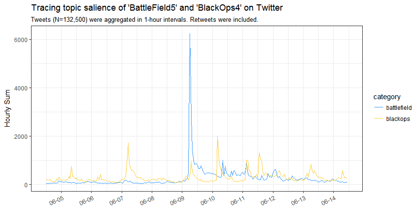

```r
tweets_hours <- meta_data %>%
  count(category, time_floor)

library(ggplot2)

tweets_hours %>%
  ggplot(aes(x=time_floor, y=n, color=category)) +
  geom_line() +
  theme_bw() +
  labs(x = NULL, y = "Hourly Sum",
       title = "Tracing topic salience of 'BattleField5' and 'BlackOps4' on Twitter",
       subtitle = "Tweets (N=132,500) were aggregated in 1-hour intervals. Retweets were included.") +
  scale_x_datetime(date_breaks = "24 hours", date_labels = "%m-%d") +
  scale_color_manual(values = c( "#3399FF", "#FFCC33")) +
  theme(axis.text.x = element_text(angle = 25, vjust = 1.0, hjust = 1.0))
```

<사진1. 시간별 트윗량 그래프>

6월9일에서 10일 사이에 배틀필드의 트윗량이 급증한 것은, 배틀필드 관련 게임 컨퍼런스가 있었기 때문이라고 사료됩니다.

# 데이터 전처리

<코드9. 단어 토큰 분리>

```r
library(tidytext)

unnest_regex <- "[^[:word:]#@]"
remove_regex <- "(https?://)[[:word:]./]+|(www\\.)[[:word:]./]+|&amp;|&lt;|&gt;|&quot;|RT"

tweets_tidy <- meta_data %>%
  mutate(text = str_replace_all(text, "[#@]?[^[:ascii:]]", "")) %>%
  mutate(text = str_replace_all(text, remove_regex, "")) %>%
  unnest_tokens(word, text, token = "regex", pattern = unnest_regex) %>%
  filter(!word %in% stop_words$word) %>%
  filter(!str_detect(word, "[#@]"))
```

## I. 단어 예외처리

<코드10. 배틀필드의 상위단어 분류>

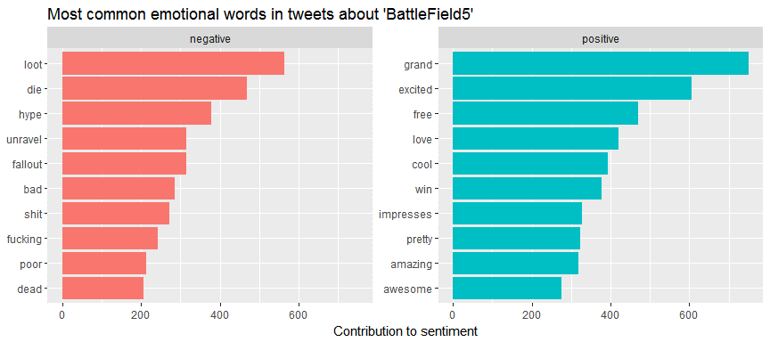

```r
bing_battlefield <- tweets_tidy %>%
  filter(category=="battlefield") %>%
  inner_join(get_sentiments("bing")) %>%
  count(category, word, sentiment, sort=TRUE) %>%
  ungroup()

bing_battlefield %>%
  group_by(sentiment) %>%
  top_n(10) %>%
  ungroup() %>%
  mutate(word = reorder(word, n)) %>%
  ggplot(aes(word, n, fill=sentiment)) +
  geom_bar(stat="identity", show.legend = FALSE) +
  facet_wrap(~sentiment, scales="free_y") +
  labs(y = "Contribution to sentiment", x = NULL,
       title = "Most common emotional words in tweets about 'BattleField5'") +
  coord_flip()
```

<사진2. 데이터 전처리 전에 도출된 배틀필드의 긍정적&부정적 단어 상위10개>

<표2. 예외처리에 해당되는 단어 상세 해석>

| 단어 | 비고 |
| --- | --- |
| loot | ‘Loot Box’(랜덤박스)라는 게임시스템 중 하나로, 이번에 배틀필드5에서 랜덤박스가 사라져 이와 관련된 트윗일 것이다 |
| hype | 게임 관련 트윗에서는 ‘X나 쩔어’의 뉘앙스로 쓰이는 경우가 많다 |
| unravel | 이번에 EA에서 새로 공개한 게임인 *Unravel Two*를 가리킬 확률이 매우 높다 |
| fallout | 해외 유명 RPG 시리즈 중 하나인 *폴아웃*을 가리킬 확률이 매우 높다 |
| free | 이번에 배틀필드5에서 dlc는 무료다 |
| tank | 2차세게계대전을 배경으로하 하는데 탱크가 나오는 것은 당연하다 |

<코드11. 콜오브듀티의 상위단어 분류>

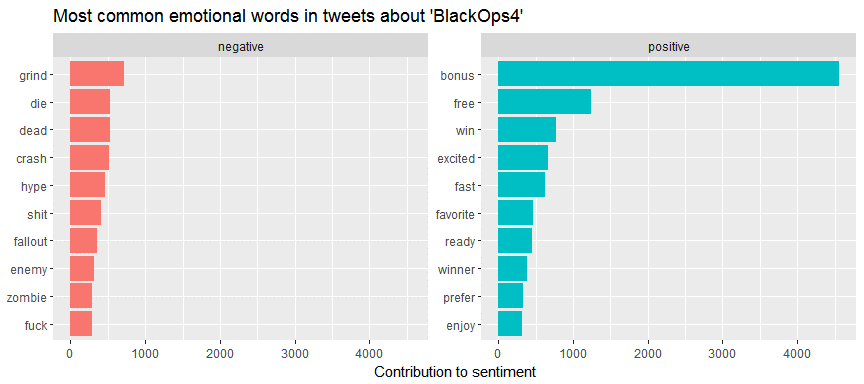

```r
bing_blackops <- tweets_tidy %>%
  filter(category=="blackops") %>%
  inner_join(get_sentiments("bing")) %>%
  count(category, word, sentiment, sort=TRUE) %>%
  ungroup()

bing_blackops %>%
  group_by(sentiment) %>%
  top_n(10) %>%
  ungroup() %>%
  mutate(word = reorder(word, n)) %>%
  ggplot(aes(word, n, fill=sentiment)) +
  geom_bar(stat="identity", show.legend = FALSE) +
  facet_wrap(~sentiment, scales="free_y") +
  labs(y = "Contribution to sentiment", x = NULL,
       title = "Most common emotional words in tweets about 'BlackOps4'") +
  coord_flip()
```

<사진3. 데이터 전처리 전에 도출된 콜오브듀티의 긍정적&부정적 단어 상위10개>

<표3. 예외처리에 해당되는 단어 상세 해석>

| 단어 | 비고 |
| --- | --- |
| grind | 게임 관련 트윗에서는 ‘인생을 갈아버릴 정도로 재밌다’, ‘다른 게임을 부셔버린다’의 뉘앙스에 더 가깝다 |
| hype | 상동 |
| fallout | 상동 |
| zombie | 게임 내의 *좀비모드*를 가릴킬 확률이 매우 높다다 |
| bonus | *#UltimateBlackOps4Giveaway* RT이벤트를 진행 중인데, 관련 트윗에 ‘bonus’ 글자가 들어가 있다 |
| free | 블랙옵스4도 관련 콘텐츠가 무료로 제공된다다 |
| enemy | 당연히 적군이 나오는 게임이다 |

## sentiment lexicon 재정립

<코드12. 단어 예외처리>

```r
except_word <- "loot|unravel|fallout|zombie|bonus|hype|grind|\\b[f][r][e][e][d]?\\b|tank|enemy"
modified_word <- data.frame(word = c("hype","over-hyped","grind","err-free","issue-free", "pain-free", "problem-free", "risk-free", "toll-free", "trouble-free"),
                            sentiment = "positive")

bing <- get_sentiments("bing") %>%
  filter(!str_detect(word, except_word))

modified_bing <-  bind_rows(bing, modified_word)
```

저는 데이터에서 단어를 삭제하는 것이 아니라, sentiment lexicon 자체를 수정하는 방식으로 예외처리를 하였습니다. 그리고 1)과 2)를 반복하면서 상위에 도출되는 단어를 확인하면서 데이터 전처리를 하였습니다.

## 상위 빈도수의 감정단어 시각화

<코드13. 배틀필드의 상위 빈도수 감정단어 시각화>

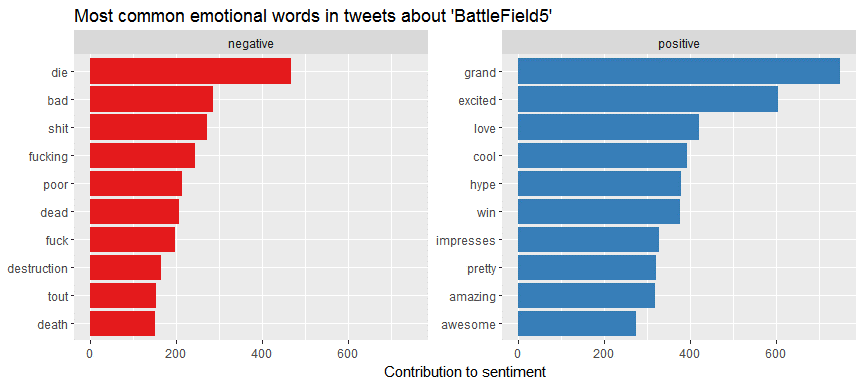

```r
tweets_tidy %>%
  filter(category=="battlefield") %>%
  inner_join(modified_bing) %>%
  count(word, sentiment, sort=TRUE) %>%
  group_by(sentiment) %>%
  top_n(10) %>%
  ungroup() %>%
  mutate(word = reorder(word, n)) %>%
  ggplot(aes(word, n, fill=sentiment)) +
  geom_bar(stat="identity", show.legend = FALSE) +
  facet_wrap(~sentiment, scales="free_y", ncol = 2) +
  labs(y = "Contribution to sentiment", x = NULL,
       title = "Most common emotional words in tweets about 'BattleField5'") +
  scale_fill_brewer(palette="Set1") +
  coord_flip()
```

<사진4. 배틀필드의 긍정적&부정적 단어>

<코드14. 콜오브듀티의 상위 빈도수 감정단어 시각화>

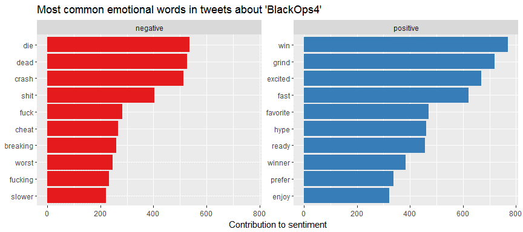

```r
tweets_tidy %>%
  filter(category=="blackops") %>%
  inner_join(modified_bing) %>%
  count(word, sentiment, sort=TRUE) %>%
  group_by(sentiment) %>%
  top_n(10) %>%
  ungroup() %>%
  mutate(word = reorder(word, n)) %>%
  ggplot(aes(word, n, fill=sentiment)) +
  geom_bar(stat="identity", show.legend = FALSE) +
  facet_wrap(~sentiment, scales="free_y") +
  labs(y = "Contribution to sentiment", x = NULL,
       title = "Most common emotional words in tweets about 'BlackOps4'") +
  scale_fill_brewer(palette="Set1") +
  coord_flip()
```

<사진5. 콜오브듀티의 긍정적&부정적 단어>

# 전체 감정 비율

<코드15. 전체 감정 시각화>

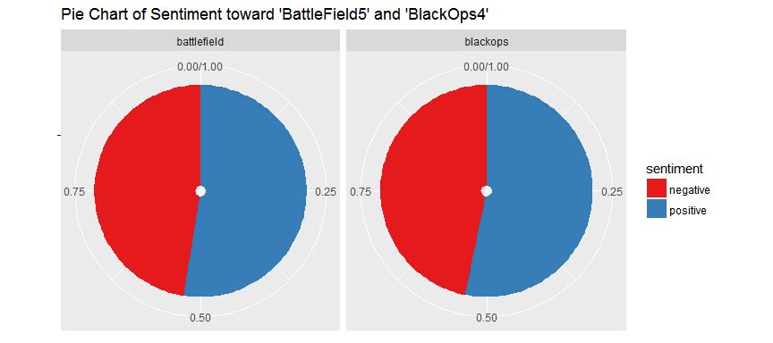

```r
tweets_tidy %>%
  inner_join(modified_bing) %>%
  count(category, sentiment, sort=TRUE) %>%
  mutate(sentiment = reorder(sentiment, n)) %>%
  ggplot(aes(x="", y=n, fill=factor(sentiment))) +
  geom_bar(stat="identity", position = position_fill()) +
  coord_polar(theta="y", start=0) +
  facet_wrap(~category) +
  labs(fill="sentiment", x=NULL, y=NULL,
       title="Pie Chart of Sentiment toward 'BattleField5' and 'BlackOps4'") +
  scale_fill_brewer(palette="Set1")
```

<사진6. 배틀필드와 콜오브듀티의 전체 감정 비율>

# 시간별 감정 비율

<코드16. 시간별 감정 비율 시각화>

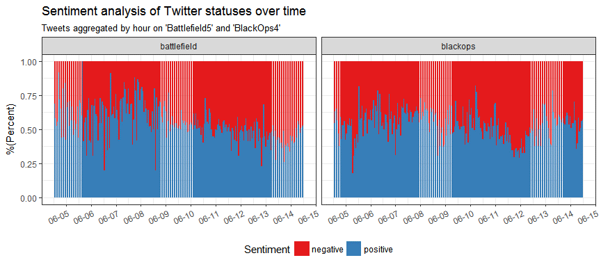

```r
tweets_tidy %>%
  inner_join(modified_bing) %>%
  count(category, time_floor, sentiment) %>%
  ggplot(aes(x=time_floor, y=n, fill=factor(sentiment))) +
  geom_bar(stat="identity", position = position_fill()) +
  facet_wrap(~category, ncol=2) +
  theme_bw() +
  theme(legend.position = "bottom") +
  labs(x = NULL, y = "%(Percent)", fill= "Sentiment",
       title = "Sentiment analysis of Twitter statuses over time",
       subtitle = "Tweets aggregated by hour on 'Battlefield5' and 'BlackOps4'") +
  scale_x_datetime(date_breaks = "24 hours", date_labels = "%m-%d") +
  scale_fill_brewer(palette="Set1") +
  theme(axis.text.x = element_text(angle = 25, vjust = 1.0, hjust = 1.0))
```

<사진7. 시간별 감정 비율>

# 연구 관련 이슈

## I. 시각화

데이터를 다른 사람들에게 더 잘 이해시키기 위해서 시각화를 하는 것이라면, 시각화 된 표 안의 색깔도 중요하다 생각합니다. 따로 지정을 안 해주면 default 색이 tomato색으로 나와 마음에 안 들었는데, 다행히 scale_color_manual()통해 원하는 부분마다 일일이 지정할 수 있었습니다. 배틀필드와 블랙옵스도 고유의 색이 존재하기에, 해당 색으로 표현하는 것이 중요하다 생각했습니다. 그리고 시각화를 화면서 알았던 사실로, **geom_line()**의 경우에는 **color**로, **geom_bar()**의 경우에는 **fill**로 구분해줘야 색이 잘 적용됨을 알았습니다.

### • 전체 감정 비율

처음에는 전체 감정 비율 그래프를 뽑아내는데, 배틀필드와 콜오브듀티 각각 도출했습니다. 그러나 그래프를 따로 첨부하면 보는 사람의 가독성에 영향을 미칠 수 있다고 판단하여 통합하는 과정을 거쳤습니다.

<코드17. 배틀필드 감정 비율 시각화>

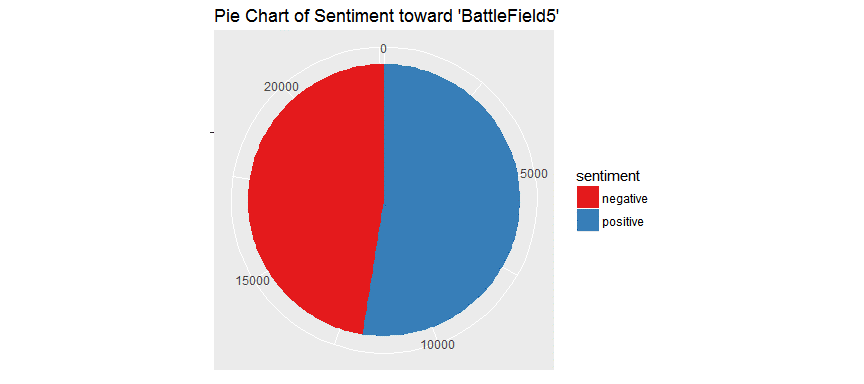

```r
tweets_tidy %>%
  filter(category=="battlefield") %>%
  inner_join(modified_bing) %>%
  count(sentiment, sort=TRUE) %>%
  mutate(sentiment = reorder(sentiment, n)) %>%
  ggplot(aes(x="", y=n, fill=factor(sentiment))) +
  geom_bar(width=1, stat="identity") +
  labs(fill="sentiment", x=NULL, y=NULL, title="Pie Chart of Sentiment toward 'BattleField5'") +
  scale_fill_brewer(palette="Set1") +
  coord_polar(theta="y", start=0)
```

<사진8. 배틀필드 감정 비율>

<코드18. 콜오브듀티 감정 비율 시각화>

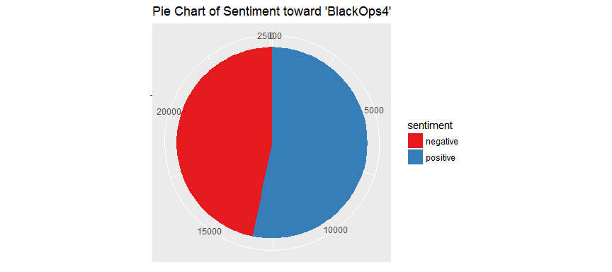

```r
tweets_tidy %>%
  filter(category=="blackops") %>%
  inner_join(modified_bing) %>%
  count(sentiment, sort=TRUE) %>%
  mutate(sentiment = reorder(sentiment, n)) %>%
  ggplot(aes(x="", y=n, fill=factor(sentiment))) +
  geom_bar(width=1, stat="identity") +
  labs(fill="sentiment", x=NULL, y=NULL, title="Pie Chart of Sentiment toward 'BlackOps4'") +
  scale_fill_brewer(palette="Set1") +
  coord_polar(theta="y", start=0)
```

<사진9. 콜오브듀티 감정 비율>

<코드19. 전체 감정 비율의 변경된 코드>

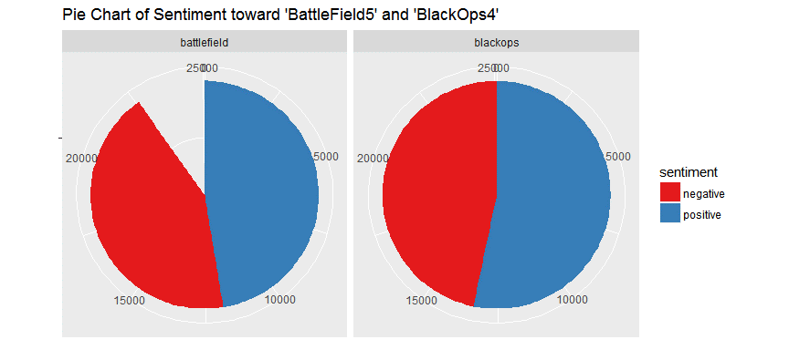

```r
tweets_tidy %>%
  inner_join(modified_bing) %>%
  count(category, sentiment, sort=TRUE) %>%
  ggplot(aes(x="", y=n, fill=factor(sentiment))) +
  geom_bar(width=1, stat="identity") +
  labs(fill="sentiment", x=NULL, y=NULL, title="Pie Chart of Sentiment toward 'BattleField5' and 'BlackOps4'") +
  scale_fill_brewer(palette="Set1") +
  coord_polar(theta="y", start=0)+
  facet_wrap(~category)
```

<사진10. 잘못 출력된 그래프>

그래서 코드를 바꿨는데 이번에는 **cartesian coord**이 아닌 경우에는 **scales**에서 **free**를 설정할 수가 없어서 더욱 불완전한 시각화가 되어버렸습니다. 그러나 해당 문제는 **position = position_fill()**를 사용하여 두 개의 pie그래프를 동시에 만들 수 있는 방법을 본 적이 있어 해결할 수 있었습니다.

### • 시간별 감정 비율

<코드20. 점을 이용하여 1시간 단위로 감정 비율 시각화>

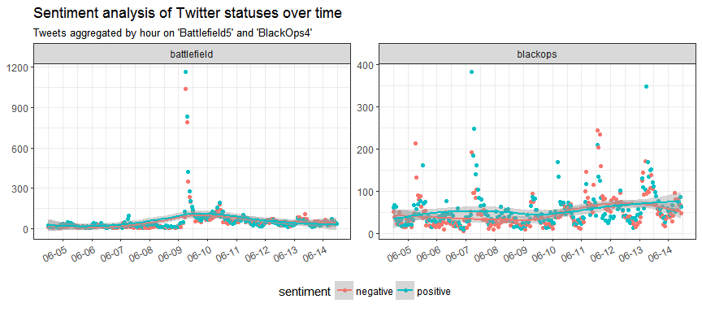

```r
tweets_tidy %>%
  inner_join(modified_bing) %>%
  count(category, time_floor, sentiment) %>%
  ggplot(aes(x=time_floor, y=n, color=sentiment)) +
  geom_point() +
  geom_smooth() +
  facet_wrap(~ category, scale="free_y", ncol=2) +
  theme_bw() +
  theme(legend.position = "bottom") +
  labs(x = NULL, y = NULL,
       title = "Sentiment analysis of Twitter statuses over time",
       subtitle = "Tweets aggregated by hour on 'Battlefield5' and 'BlackOps4'") +
  scale_x_datetime(date_breaks = "24 hours", date_labels = "%m-%d") +
  theme(axis.text.x = element_text(angle = 25, vjust = 1.0, hjust = 1.0))
```

<사진11. 점을 이용한 1시간 단위 감정 비율>

처음에는 **geom_point()**와 **geom_smooth()**를 사용했는데, 전혀 정보를 전달할 수 없는 결과물이 나왔습니다. 아무래도 한 시간 단위로 데이터를 나누다 보니 너무 촘촘해져서 제대로 표현되기 어렵다고 생각했습니다. 그래서 다음에는 하루 단위로 감정빈도를 통합해보았습니다.

<코드21. 점을 이용하여 1일 단위로 감정 비율 시각화>

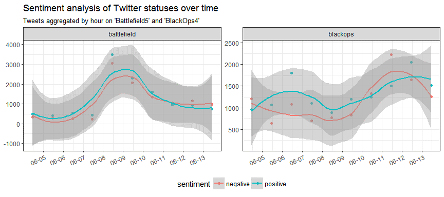

```r
tweets_sentiment_day <- tweets_tidy %>%
  inner_join(modified_bing) %>%
  mutate(time_floor = floor_date(time_floor, unit = "day")) %>%
  count(category, time_floor, sentiment)

tweets_sentiment_day %>%
  ggplot(aes(x=time_floor, y=n, color=sentiment)) +
  geom_point() +
  geom_smooth() +
  facet_wrap(~ category, scale="free_y", ncol=2) +
  theme_bw() +
  theme(legend.position = "bottom") +
  labs(x = NULL, y = NULL,
       title = "Sentiment analysis of Twitter statuses over time",
       subtitle = "Tweets aggregated by hour on 'Battlefield5' and 'BlackOps4'") +
  scale_x_datetime(date_breaks = "24 hours", date_labels = "%m-%d") +
  theme(axis.text.x = element_text(angle = 25, vjust = 1.0, hjust = 1.0))
```

<사진12. 점을 이용한 1일 단위 감정 비율>

하지만 이 또한 point와 smooth가 일치하지 않기 때문에 완전한 시각화가 아니라고 판단했습니다.

<코드22. 선을 이용하여 감정 비율 시각화>

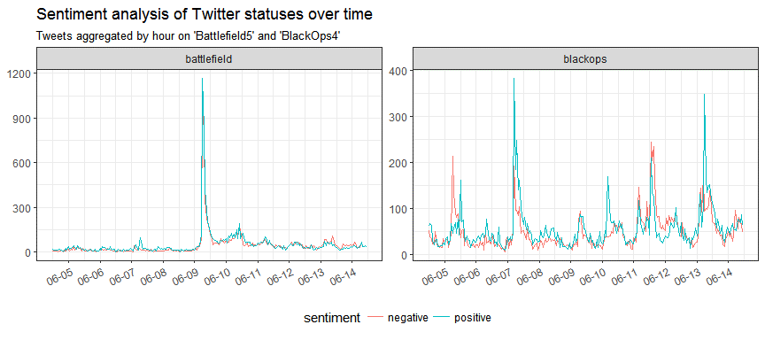

```r
tweets_tidy %>%
  inner_join(modified_bing) %>%
  count(category, time_floor, sentiment) %>%
  ggplot(aes(x=time_floor, y=n, color=sentiment)) +
  geom_line() +
  facet_wrap(~ category, scale="free_y", ncol=2) +
  theme_bw() +
  theme(legend.position = "bottom") +
  labs(x = NULL, y = NULL,
       title = "Sentiment analysis of Twitter statuses over time",
       subtitle = "Tweets aggregated by hour on 'Battlefield5' and 'BlackOps4'") +
  scale_x_datetime(date_breaks = "24 hours", date_labels = "%m-%d") +
  theme(axis.text.x = element_text(angle = 25, vjust = 1.0, hjust = 1.0))
```

<사진13. 선을 이용한 감정 비율>

**geom_line()**으로 표현해보니 이전보다 확실히 나아졌지만, 해당 그래프는 감정의 절대값을 보여주는 것이기 때문에 한계가 있다고 판단했습니다. 감정 분석에서는 절대값보다는 긍정과 부정의 비율이 더욱 중요하다고 판단하여, 결국 최종적으로는 비율을 알 수 있는 그래프를 채택하였습니다.

## lexicon 기반 감정 분석

lexicon 기반의 감정분석은 가장 기본적인 감정분석 방법 중 하나인지만, 전체적인 경향성을 파악하는데 부족하지 않습니다. 또한 가장 기초적인 감정분석이기에, 오히려 이를 바탕으로 연구자가 자신의 시선을 적용하여 얼마든지 발전 가능성이 큽니다. 따라서 저는 해당 연구에서 bing lexicon을 사용하였습니다. 이는 수집한 데이터가 트위터 데이터이니, 트위터 데이터를 기반으로 만들어진 bing lexicon이 더 적절하다고 판단했습니다. 또한, 속보성과 확산성을 강조하는 트위터의 성격과 그에 따른 트윗의 140자 제한을 고려한다면, 이용자들의 텍스트가 그리 길다고 할 수 없는데 이를 nrc 같은 10개의 감정으로 분석하는 것은 크게 의미 없다고 생각했습니다. 만약 특정 주제에 관한 입장문을 분석한다면 nrc가 어울리겠지만, 제 주제의 경우 게임이며, 실제로 게임 관련 트위터 데이터를 모으는 상황을 상정한다면, 긍정/부정 반응 정도를 확인하는 거지 그 이상의 감정분석을 진행하지는 않을 거라 생각했습니다. 또한 게임을 하는 이용자들은 트위터에 게임 관련된 주로 사진이나 동영상을 많이 올리지, 텍스트 자체에서 감정을 크게 표현하지는 않는다는 점에서도 이유를 들 수 있습니다. 그나마 bing lexicon의 경우, unique한 단어 수가 가장 많아(6785개) 경우의 수를 가장 잘 모을 수 있으며, 감정이 긍정/부정으로 확실하기에, 연구자가 특정 주제에 대한 지식이 풍부하다면 lexicon의 수정 또한 용이하기에 최종적으로 bing lexicon을 사용하였습니다.

그러나 bing lexicon은 uniword만 분석한다는 명확한 한계를 가지고 있으며, 데이터를 수집하는 소스에 따라 유용성이 달라지는데, 앞서 말씀드렸듯이, 예를 들어 트위터의 경우에는 사진이나 동영상만을 올리는 것으로도 사용자의 감정을 내포하는 경우가 있는데, 이는 lexicon 기반의 감정분석으로는 파악할 수 없습니다. 제가 수집한 데이터의 경우에도 수집한 트윗량(132,500개)에 비해 최종 단어 수(901,262개)가 크게 많다고 보기 어려웠습니다. 심지어 여기서 감정단어를 추려내면 총 47,662개까지 축소되었습니다.

결론적으로 lexicon 기반의 감정분석은 1) 데이터 **소스**가 어디인가 2) 데이터 **주제**가 무엇인가를 고려하고, 알맞은 lexicon을 사용한다면 충분히 매력적인 감정분석이라 생각합니다.